```python
import numpy as np
import matplotlib.pyplot as plt
import scipy as sp
import pandas as pd
```

# Datasets

## Temper

```python
df_temper = np.load("temper.npz")
```

```python
# Display "villes"

temper_villes = df_temper["villes"]
```

```python
# Set data in pandas DataFrame

temper_data_np = df_temper["data"][:,:12]
temper_data = pd.DataFrame(temper_data_np, index = temper_villes)
temper_data
```

|  | 0 | 1 | 2 | 3 | 4 | 5 | 6 | 7 | 8 | 9 | 10 | 11 |
| --- | --- | --- | --- | --- | --- | --- | --- | --- | --- | --- | --- | --- |
| Bordeaux | 5.6 | 6.6 | 10.3 | 12.8 | 15.8 | 19.3 | 20.9 | 21.0 | 18.6 | 13.8 | 9.1 | 6.2 |
| Brest | 6.1 | 5.8 | 7.8 | 9.2 | 11.6 | 14.4 | 15.6 | 16.0 | 14.7 | 12.0 | 9.0 | 7.0 |
| Clermont-Ferrand | 2.6 | 3.7 | 7.5 | 10.3 | 13.8 | 17.3 | 19.4 | 19.1 | 16.2 | 11.2 | 6.6 | 3.6 |
| Grenoble | 1.5 | 3.2 | 7.7 | 10.6 | 14.5 | 17.8 | 20.1 | 19.5 | 16.7 | 11.4 | 6.5 | 2.3 |
| Lille | 2.4 | 2.9 | 6.0 | 8.9 | 12.4 | 15.3 | 17.1 | 17.1 | 14.7 | 10.4 | 6.1 | 3.5 |
| Lyon | 2.1 | 3.3 | 7.7 | 10.9 | 14.9 | 18.5 | 20.7 | 20.1 | 16.9 | 11.4 | 6.7 | 3.1 |
| Marseille | 5.5 | 6.6 | 10.0 | 13.0 | 16.8 | 20.8 | 23.3 | 22.8 | 19.9 | 15.0 | 10.2 | 6.9 |
| Montpellier | 5.6 | 6.7 | 9.9 | 12.8 | 16.2 | 20.1 | 22.7 | 22.3 | 19.3 | 14.6 | 10.0 | 6.5 |
| Nantes | 5.0 | 5.3 | 8.4 | 10.8 | 13.9 | 17.2 | 18.8 | 18.6 | 16.4 | 12.2 | 8.2 | 5.5 |
| Nice | 7.5 | 8.5 | 10.8 | 13.3 | 16.7 | 20.1 | 22.7 | 22.5 | 20.3 | 16.0 | 11.5 | 8.2 |
| Paris | 3.4 | 4.1 | 7.6 | 10.7 | 14.3 | 17.5 | 19.1 | 18.7 | 16.0 | 11.4 | 7.1 | 4.3 |
| Rennes | 4.8 | 5.3 | 7.9 | 10.1 | 13.1 | 16.2 | 17.9 | 17.8 | 15.7 | 11.6 | 7.8 | 5.4 |
| Strasbourg | 0.4 | 1.5 | 5.6 | 9.8 | 14.0 | 17.2 | 19.0 | 18.3 | 15.1 | 9.5 | 4.9 | 1.3 |
| Toulouse | 4.7 | 5.6 | 9.2 | 11.6 | 14.9 | 18.7 | 20.9 | 20.9 | 18.3 | 13.3 | 8.6 | 5.5 |
| Vichy | 2.4 | 3.4 | 7.1 | 9.9 | 13.6 | 17.1 | 19.3 | 18.8 | 16.0 | 11.0 | 6.6 | 3.4 |

```python
temper_mean = temper_data.mean(axis = 1)
```

```python
# Set citie's coordinates in pandas DataFrame

city_coords_np = df_temper["data"][:,12:]
city_coords = pd.DataFrame(city_coords_np, index = temper_villes, columns=df_temper["varname"][-2:])
city_coords
```

|  | Latitude | Longitude |
| --- | --- | --- |
| Bordeaux | 44.5 | -0.34 |
| Brest | 48.2 | -4.29 |
| Clermont-Ferrand | 45.5 | 3.05 |
| Grenoble | 45.1 | 5.43 |
| Lille | 50.4 | 3.04 |
| Lyon | 45.5 | 4.51 |
| Marseille | 43.2 | 5.24 |
| Montpellier | 43.4 | 3.53 |
| Nantes | 47.1 | -1.33 |
| Nice | 43.4 | 7.15 |
| Paris | 48.5 | 2.20 |
| Rennes | 48.1 | -1.41 |
| Strasbourg | 48.4 | 7.45 |
| Toulouse | 43.4 | 1.26 |
| Vichy | 46.1 | 3.26 |

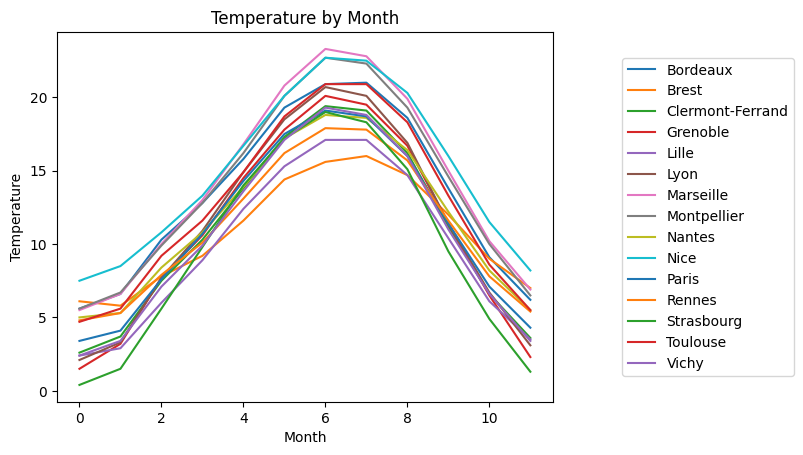

```python
# Display Temperature Data

plt.figure()
for city in temper_villes :
    plt.plot(temper_data.columns, temper_data.loc[city], label = city)
plt.xlabel("Month")
plt.ylabel("Temperature")
plt.title("Temperature by Month")
plt.legend(loc = "right", bbox_to_anchor = (1.5,0.5))
plt.show()
```

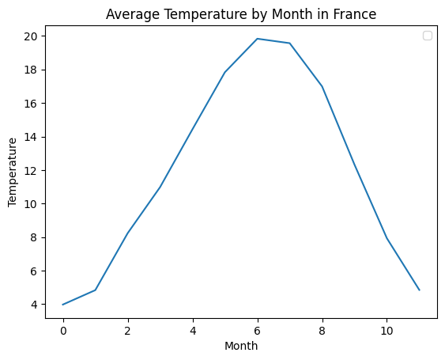

```python
# Display Average Temperature for each Month

plt.figure()
plt.plot(temper_data.columns, temper_data.mean(axis = 0))
plt.xlabel("Month")
plt.ylabel("Temperature")
plt.title("Average Temperature by Month in France")
plt.legend()
plt.show()
```

```python
# Display Cities

def display_cities(temper_mean) :
    plt.figure()
    x, y = city_coords.Longitude, city_coords.Latitude
    plt.scatter(x, y, c = temper_mean, cmap = 'viridis')
    for i in range(len(x)) :
        plt.annotate(np.array(city_coords.index)[i], (x[i], y[i]))
    plt.grid(True)
    plt.colorbar()
    plt.title("Position of cities in France + average temperature by year")
    plt.show()
```

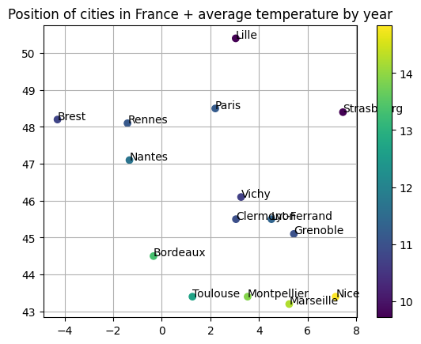

```python
display_cities(temper_data.mean(axis = 1))
```

## Digits

```python
digit_data = np.load("digits.npz")
digit_data
```

```
NpzFile 'digits.npz' with keys: xt, yt, y, x
```

xt, yt, x and y contains the same kind of data, let's vizualize some points of xt

```python
xt = digit_data["x"]

# Let's regularize the data :
xt = xt.astype(np.float64)/255

rd_idx = np.random.randint(0, len(xt), 45)

imgs = xt[rd_idx]
rd_idx
```

```
array([1620,  339, 1610,  954, 1559, 2967,  397, 1424, 2341, 1416,  124,
        435,  739, 2813,  945, 2156,   82, 2611, 1722,  660, 1608, 1179,
        892, 1937, 1013, 2511, 1840, 1609, 2002, 1142, 1915, 2270, 1349,
       2246,  800,  560,  211, 1782, 2129, 1900, 1341, 1466, 2536, 2626,
        171])
```

```python
## Defining a function to plot images
def display_images(imgs) :
    fig, axs = plt.subplots((len(imgs)-1)//15 +1 ,min(len(imgs), 15))
    for i in range(len(imgs)):
        img = [imgs[i][t*28:(t+1)*28] for t in range(28)]
        if (len(imgs)-1)//15 > 0 :
            axs[i//15, i%15].axis('off')
            axs[i//15, i%15].imshow(img, cmap = "gray")
        else :
            axs[i%15].axis('off')
            axs[i%15].imshow(img, cmap = "gray")
    plt.tight_layout()
    plt.show()
```

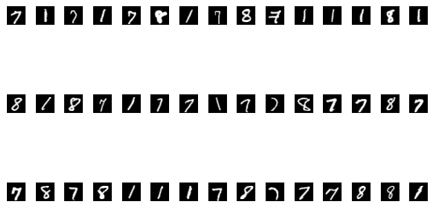

```python
display_images(imgs)
```

# Clustering

```python
from sklearn import cluster
```

## Temperature

```python
kmeans = cluster.KMeans(3, random_state=42)
```

```python
temper_kmeans = kmeans.fit(temper_data)
temper_clusters = temper_kmeans.labels_
cmap = ['orange', 'g', 'c', 'r', 'b']
```

```python
temper_centers = temper_kmeans.cluster_centers_
```

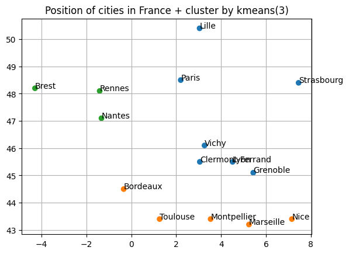

```python
# Display cluster geographically

plt.figure()
x, y = city_coords.Longitude, city_coords.Latitude
plt.scatter(x, y, c = temper_clusters, cmap = 'tab10', vmax = 9)
for i in range(len(x)) :
    plt.annotate(np.array(city_coords.index)[i], (x[i], y[i]))
plt.grid(True)
plt.title("Position of cities in France + cluster by kmeans(3)")
plt.show()
```

We can observe that the kmeans clustering is separating the cities in three delimited geographical groups and that the orange cluster is regrouping the warmest cities by comparing with the precendent geographical display. Also the green and blue clusters seems undifferentibale regarding average temperature through the year.

```python
temper_clusters_bycity = {key : value for key, value in zip(temper_villes, temper_clusters)}
```

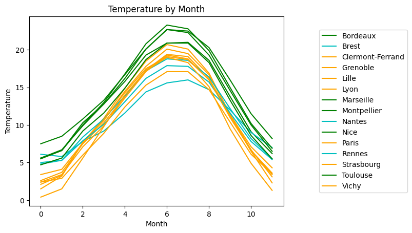

```python
# Display Temperature colored by clusters

plt.figure()
for city in temper_villes :
    plt.plot(temper_data.columns, temper_data.loc[city], label = city, c = cmap[temper_clusters_bycity[city]])
plt.xlabel("Month")
plt.ylabel("Temperature")
plt.title("Temperature by Month")
plt.legend(loc = "right", bbox_to_anchor = (1.5,0.5))
plt.show()
```

```python
def display_profiles(curves, monthes = temper_data.columns, labels = None, cmap = None) :
    kwargs = {}
    if cmap is not None :
        kwargs["c"] = cmap
    for i in range(len(curves)) :
        if labels is not None :
            kwargs["label"] = labels[i]
        plt.plot(monthes, curves[i], **kwargs)
    plt.xlabel("Month")
    plt.ylabel("Temperature")
    plt.title("Temperature by Month")
    plt.legend(loc = "right", bbox_to_anchor = (1.5,0.5))
```

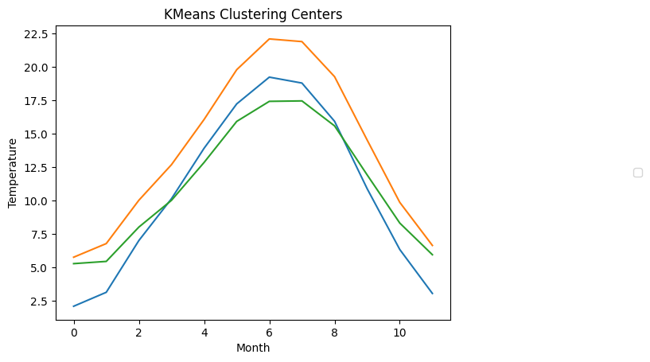

```python
# Display Cluster centers
display_profiles(temper_centers)
plt.title("KMeans Clustering Centers")
plt.show()
```

Within this graph we can observe that the blue and green clusters differentiate by the variance of their temperature through the year. By putting this observation in perspective with the geo can guess that blue cluster correspond to a continental climate while the green one corresponds to an oceanic climate.

Now let's determinate the optimal number of clusters using the elbow method. This method requires to fit kmeans on the data for increasing values of the number of clusters and observe the evolution of the inertia of resulting clusters

```python
Kmax = 11
inertia = []
centers = []
clusters = []
```

```python
## Compute and display inertia

for i in range(1, 11) :
    kmeans = cluster.KMeans(i, random_state = 42)
    kmeans.fit(temper_data)
    inertia.append(kmeans.inertia_)
    centers.append(kmeans.cluster_centers_)
    clusters.append(kmeans.labels_)
```

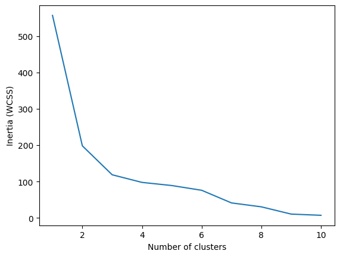

```python
plt.figure()
plt.plot(np.arange(1,11), inertia)
plt.xlabel("Number of clusters")
plt.ylabel("Inertia (WCSS)")
plt.show()
```

K = 3 seems to be the optimal value of the temperature data

To make sure the choice we made is the good one, let's display temperature means for K = 2 and K = 5

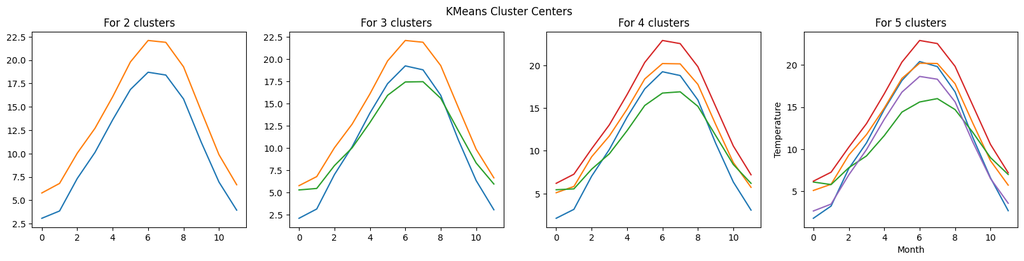

```python
fig, axs = plt.subplots(1,4, figsize = (20,4))

for i in range(1,5):
    centers_temp = centers[i]
    for j in range(len(centers_temp)) :
        axs[i-1].plot(temper_data.columns, centers_temp[j])
        axs[i-1].set_title(f"For {i+1} clusters")

plt.suptitle("KMeans Cluster Centers")
plt.xlabel("Month")
plt.ylabel("Temperature")
plt.show()
```

We can observe that :

- For two clusters all the coldest cities are in the same cluster, that is quite a rough simplification of the different temperature variation present in these cities (visible on the centers of the 3 clusters).
- For four or more clusters, even if some clusters are close to be a translation of an other cluster, some differences seems to appear on the middle of the curve (for example in the 4 and 5 clusters curves, the red curve seems to be sharper than the orange). Discerning these differences don't seem to have a huge impact on the inertia but could be relevant to have a more precise clustering regarding the profile of temperature.

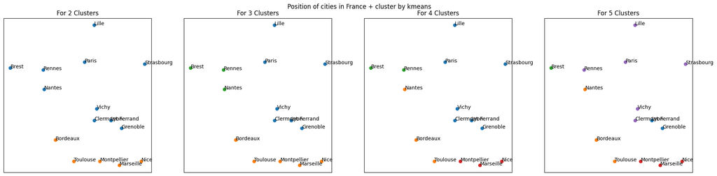

```python
# Display cluster geographically

fig, axs = plt.subplots(1,4, figsize = (20,5))

x, y = city_coords.Longitude, city_coords.Latitude
for i in range(1,5) :
    axs[i-1].scatter(x, y, c = clusters[i], cmap = 'tab10', vmax = 9)
    axs[i-1].set_title(f"For {i+1} Clusters")
    axs[i-1].set_xticks([])
    axs[i-1].set_yticks([])
    for j in range(len(x)) :
        axs[i-1].annotate(np.array(city_coords.index)[j], (x[j], y[j]))
plt.tight_layout(pad=2.0)
plt.suptitle("Position of cities in France + cluster by kmeans")
plt.show()
```

By observing the repartition of the clusters on the french map we can observe that :

- Augmenting the number of clusters bring some interesting specifications. Indeed for 5 clusters cities which are close to the alps have their own cluster and hotter cities are splitted between mediterranean coast cities and cities further to the coast (as Toulouse and Bordeaux).
- But the clusters defined by the 3-clusters kmeans algorithm are fluctuating while the number of clusters augments (ex : Nantes is integrated in the Toulouse's and Bordeaux's group). Also, the number of points being 15, too much clusters could lead to risks of overfitting (indeed it's already over the empirical maximum of clusters equal to $\sqrt(15) = 3.87$).

To conclude raising the number of clusters can lead to more subtle climate differentation but can also break the more simple and 'evident' groups we have for 3 clusters. Depending on the precise objective of a data scientist a number 3, 4 or 5 clusters can be interesting. We don't go into further numbers of clusters as putting one cluster for two points will sure lead to overfitting

## Digits

```python
X_digits = digit_data['x']
X_digits
```

```
array([[0, 0, 0, ..., 0, 0, 0],
       [0, 0, 0, ..., 0, 0, 0],
       [0, 0, 0, ..., 0, 0, 0],
       ...,
       [0, 0, 0, ..., 0, 0, 0],
       [0, 0, 0, ..., 0, 0, 0],
       [0, 0, 0, ..., 0, 0, 0]], shape=(3000, 784), dtype=uint8)
```

```python
kmeans_digits = cluster.KMeans(3, random_state=42)
kmeans_digits.fit(X_digits)
```

```
KMeans(n_clusters=3, random_state=42)
```

```python
centroids_digits = kmeans_digits.cluster_centers_
labels_digits = kmeans_digits.labels_
```

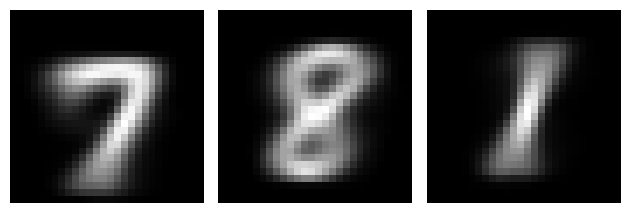

```python
display_images(centroids_digits)
```

These centroids seems to correspond to a generic (widely comparable) version of each number represented on the data. Indeed these centroids don't seem to correspond to real data points as they have a bit of blur and are thicker than a random image :

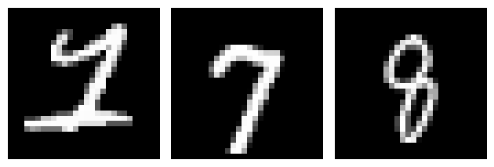

```python
display_images([X_digits[500 + 1000*i] for i in range(3)])
```

To determinate the adequate number of clusters let's try to use the elbow method (we fix the maximal number of clusters at 55 as $\sqrt(3000) = 54.8$)

```python
## Compute and display inertia

Kmax = 55
inertia_digits = []
kmeans = []

for i in range(1, Kmax) :
    kmeans_temp = cluster.KMeans(i, random_state = 42)
    kmeans_temp.fit(X_digits)
    kmeans.append(kmeans_temp)
    inertia_digits.append(kmeans_temp.inertia_)
```

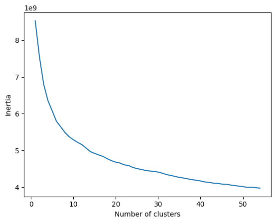

```python
plt.figure()
plt.plot(np.arange(1,Kmax), inertia_digits)
plt.xlabel("Number of clusters")
plt.ylabel("Inertia")
plt.show()
```

Here the inertia curve is too smooth to select a proper optimal value of k, let's compute other clustering performance evaluation :

```python
## Compute Silhouette and Davis Boudlin Scores

from sklearn.metrics import davies_bouldin_score
from sklearn.metrics import silhouette_score

sil = []
dbs = []

for i in range(1, Kmax-1) :
    kmeans_temp = kmeans[i]
    sil.append(silhouette_score(X_digits, kmeans_temp.labels_))
    dbs.append(davies_bouldin_score(X_digits, kmeans_temp.labels_))
```

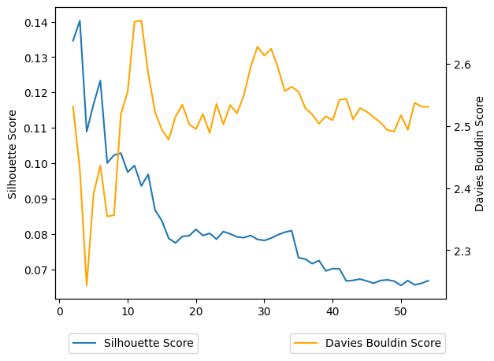

```python
fig, ax1 = plt.subplots()

ax1.plot(np.arange(2,Kmax), sil, label = "Silhouette Score")
ax1.set_ylabel("Silhouette Score")
ax1.legend(loc='upper center', bbox_to_anchor=(0.2, -0.1))
ax2 = ax1.twinx()
ax2.set_ylabel("Davies Bouldin Score")
ax2.plot(np.arange(2,Kmax), dbs, color = 'orange', label = "Davies Bouldin Score")
ax2.legend(loc='upper center', bbox_to_anchor=(0.8, -0.1))

plt.xlabel("Number of clusters")
plt.show()
```

```python
nb_opt_sil = np.argmax(sil) + 2
nb_opt_dbs = np.argmin(dbs) + 2
nb_opt_sil, nb_opt_dbs
```

```
(np.int64(3), np.int64(4))
```

- According to the Silhouette Score, the best number of clusters is 3
- According to the Davies Boudlin Score it is 4

Let's vizualize the centroids of kmeans clustering for 4 and 5 clusters :

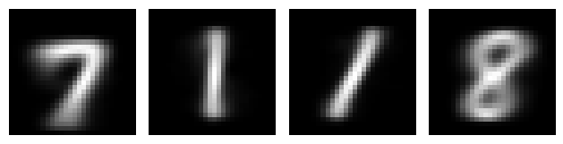

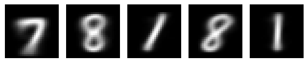

```python
display_images(kmeans[3].cluster_centers_)
display_images(kmeans[4].cluster_centers_)
```

We can observe that the supplementary clusters created allow to distinguish different typos for a number. As we want to differenciate the number augmenting the number of clusters don't seem pertinent : we keep a value of k = 3.